# Basic Plotting With `ggplot2`

ASI: Introduction to R

Author

Affiliation

Dr Stevie Pederson

Black Ochre Data Labs  
Telethon Kids Institute

Published

November 21, 2023

# Basic Data Visualisation

## Data Visualisation

- Now we know how to import data $\implies$ *what does it look like?*

. . .

- Traditionally `R` used functions from `base` and `graphics`

. . .

- The main plotting package from the `tidyverse` is `ggplot2`
  - Incredibly powerful approach to plotting
  - Uses an approach known as “Grammar of Graphics” (`gg`)
- Less intuitive than traditional `R` plots
  - Far simpler after some practice
  - Much more powerful

## Setup For This Section

1. Clear your R Environment
2. Create a new R script called `IntroVisualisation.R`
3. Copy the following chunk from the earlier section

```r
library(tidyverse)
pigs <- read_csv("data/pigs.csv")
glimpse(pigs)
```

```
Rows: 60
Columns: 3
$ len  <dbl> 4.2, 11.5, 7.3, 5.8, 6.4, 10.0, 11.2, 11.2, 5.2, 7.0, 16.5, 16.5,…
$ supp <chr> "VC", "VC", "VC", "VC", "VC", "VC", "VC", "VC", "VC", "VC", "VC",…
$ dose <chr> "Low", "Low", "Low", "Low", "Low", "Low", "Low", "Low", "Low", "L…
```

## Plotting using `base`

`cars` is a 2-column data.frame that `R` provides for making examples

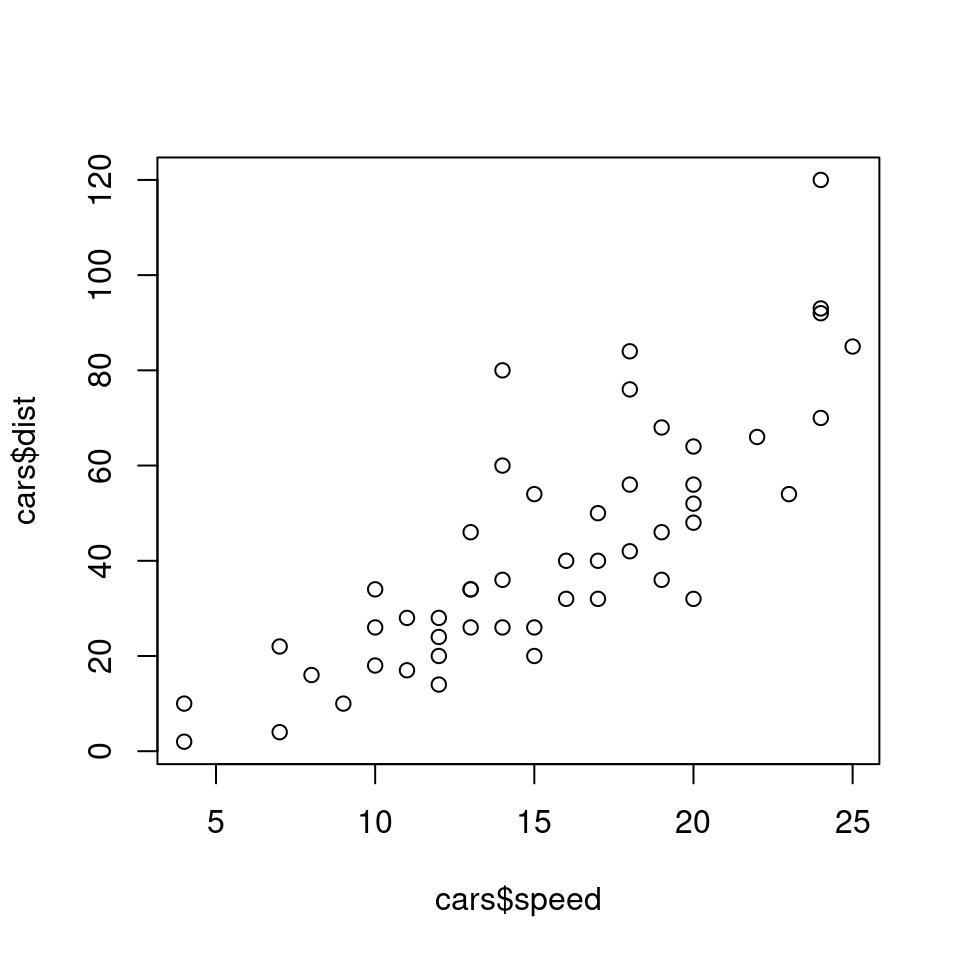

Distance taken to stop shown as a function of a car’s speed

```r
plot(cars$speed, cars$dist)
```

- This is a basic `x` vs `y` plot
- Simple plots are pretty customisable
- Good for *quick & dirty* looks at data

## Histograms

- Histograms using `hist()` can be pretty useful

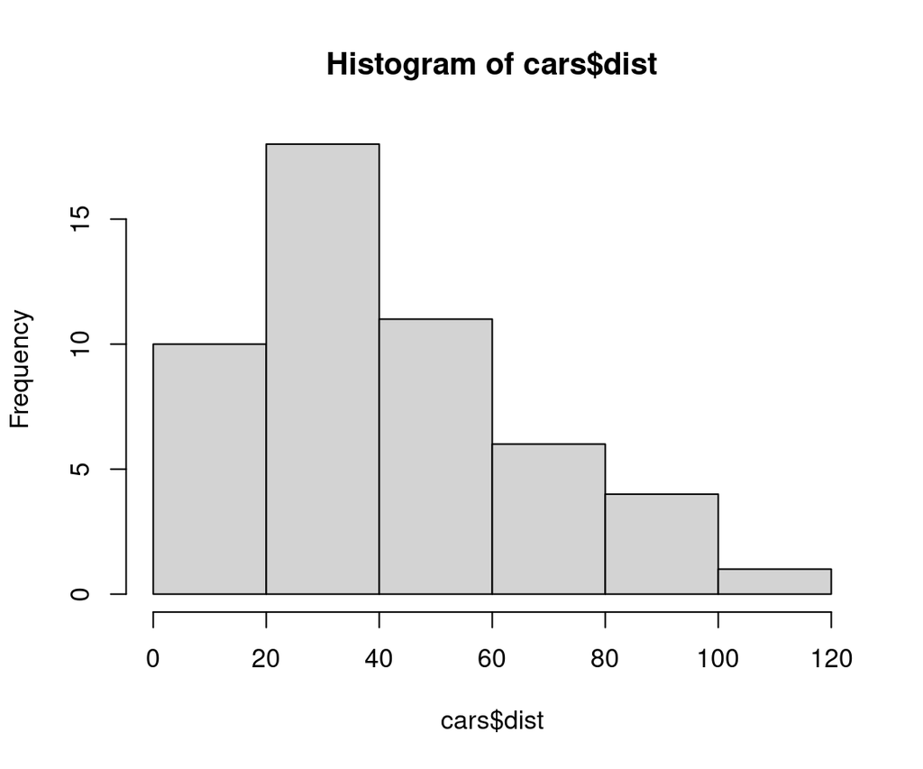

```r
hist(cars$dist)
```

## Boxplots using `base`

- Boxplots usually require a grouping variable on the x-axis
  - Use `pigs` specifying `dose` as the grouping variable
- The formula syntax `len ~ dose` $\implies$ `len` “depends on” `dose`
  - Predictor (`dose`) on the x-axis $\implies$ Response (`len`) on the y-axis

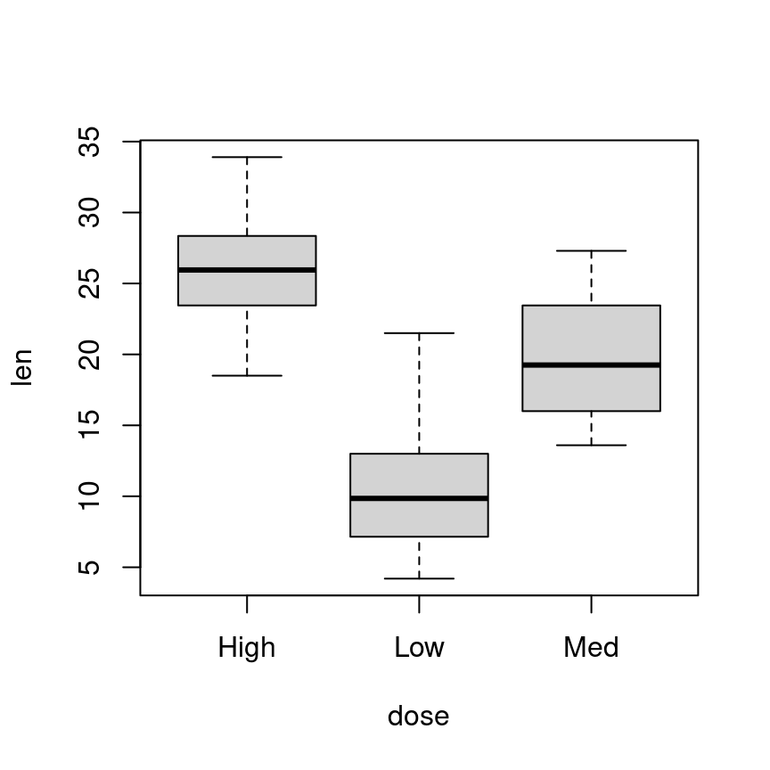

```r
boxplot(len ~ dose, data = pigs)
```

Note that the x-axis is showing dose level in alphabetical order

# Using `ggplot2`

## `ggplot2` Basics

Instead of a single function $\implies$ build a plot using *multiple layers*

1. Start by defining the data object
   - Values for `x` & `y` axes usually defined here
2. Add layers defining the *geometry* to use
   - May be points (`geom_point`), boxplots (`geom_boxplot`) etc
   - Text overlays (`annotate`) or regression lines (`stat_smooth`)

. . .

3. *Optionally* split into panels or facets
4. *Optionally* modify any scales used
5. *Optionally* tidy up labels
6. *Optionally* define an overall plotting theme

## A simple boxplot

- What values are the response variable? `len`
- What values are the predictor variable? Either `dose` or `supp`

. . .

- Let’s start putting `dose` on the x-axis

## A simple boxplot

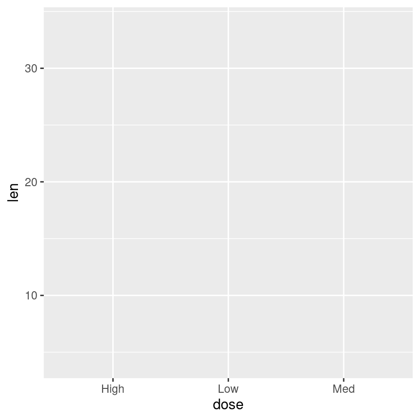

```r
ggplot(
    data = pigs,
    mapping = aes(x = dose, y = len)
)
```

. . .

- We specified the values to be placed on `x` and `y` $\implies$ axes were drawn
  - Defined as *aesthetic mappings* using `aes()`

. . .

- **We haven’t added any geometry so none is drawn**

## A simple boxplot

- Geometry is added by
  1. Placing a `+` at the end of the first line
  2. Calling a `geom_*` function, e.g. `geom_boxplot()`

. . .

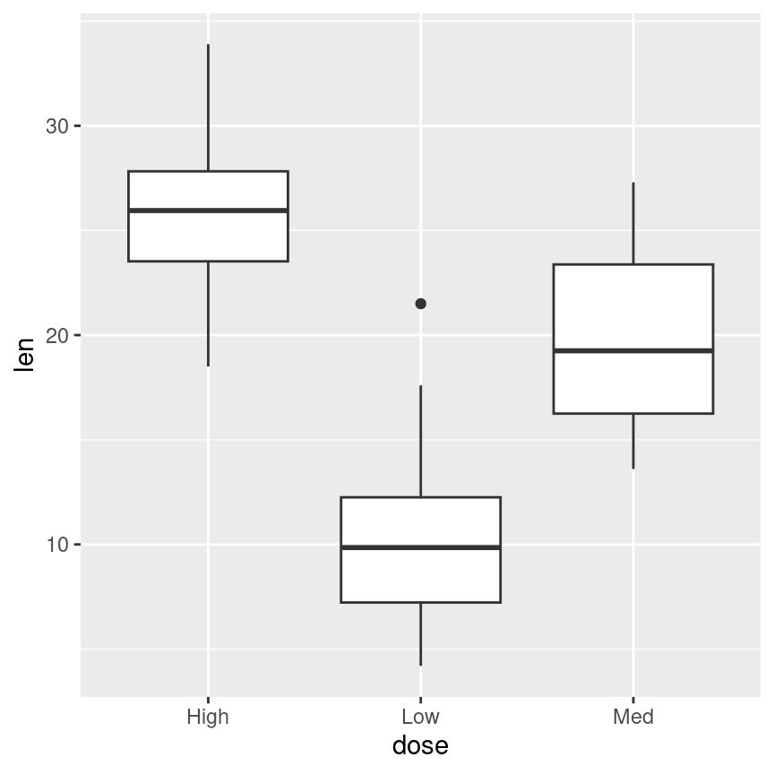

```r
ggplot(
    data = pigs,
    mapping = aes(x = dose, y = len)
) +
  geom_boxplot()
```

Any mappings provided to `aes()` in the initial call are passed to subsequent `geom_*` functions

## Using Colours

- We can add more mappings to `aes()`
  - Show the supplement method as the boxplot fill

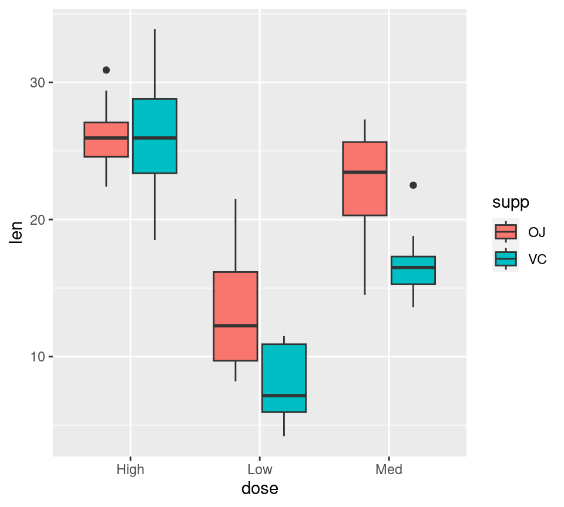

```r
ggplot(
    data = pigs,
    mapping = aes(x = dose, y = len, fill = supp)
) +
  geom_boxplot()
```

## Using Colours

- We can change the palette using `scale_fill_*`

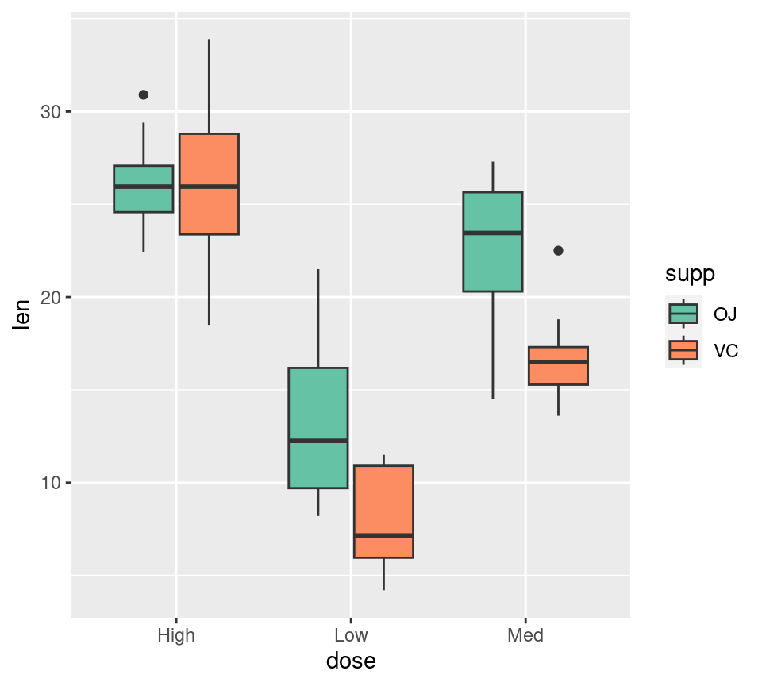

```r
ggplot(
    data = pigs,
    mapping = aes(x = dose, y = len, fill = supp)
) +
  geom_boxplot() +
  scale_fill_brewer(palette = "Set2")
```

## `scale_fill_*()`

- There are multiple options for defining colour palettes (i.e. scales)
  - `scale_fill_discrete()` is applied by default
  - `scale_fill_viridis_d()` (`_d` for discrete)
  - `scale_fill_grey()`
  - `scale_fill_manual()`
  - …
- We will explore more of these as we learn more
  - Difference between *discrete* & *continuous* values is important
- Colour/Fill palettes:
  - `colour` is for shape outlines
  - `fill` is for filled shapes

Hadley Wickham is from NZ so he uses the correct spelling of colour ggplot2 can recognise both…

## Using Existing Themes

- We can get rid of the horrible grey background using a `theme()`

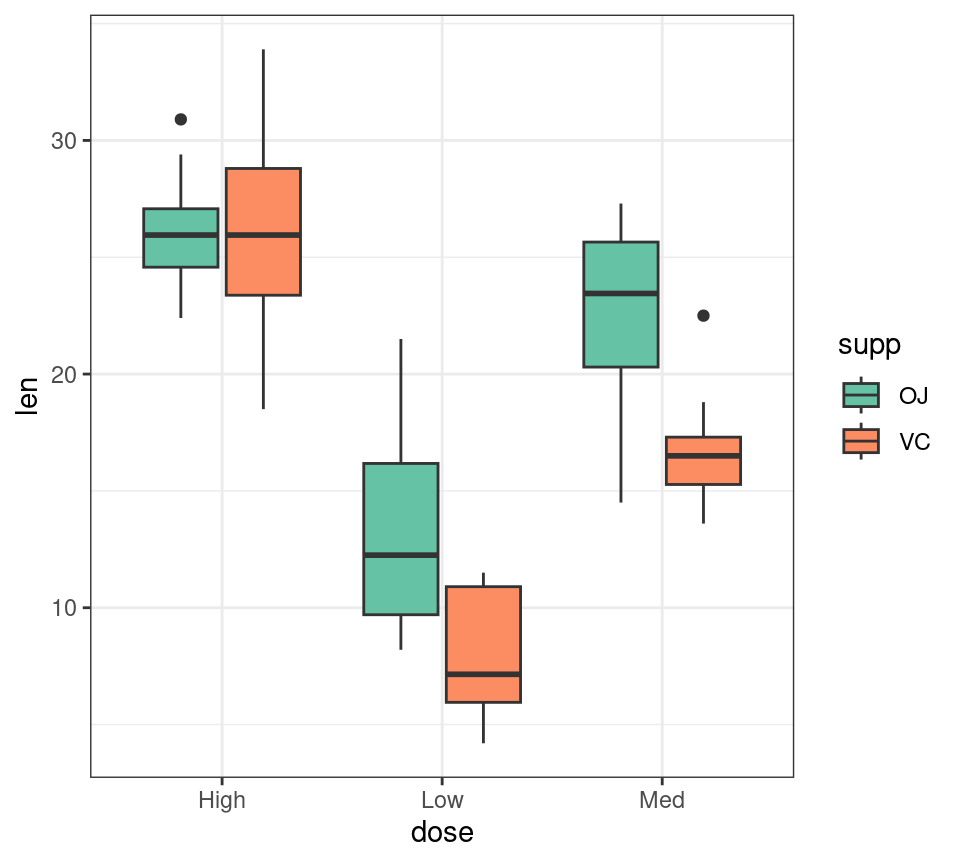

```r
ggplot(
  pigs, aes(x = dose, y = len, fill = supp)
) +
  geom_boxplot() +
  scale_fill_brewer(palette = "Set2") +
  theme_bw()
```

## `theme_bw()`

- `theme_bw()` is my default for how plots look
  - `theme_grey()` is the default
  - Other complete themes: `theme_classic()`, `theme_minimal()`
- Adding `theme()` can modify the overall layout
  - `legend.position`, `legend.justiication`
  - `axis.text`, `axis.tixks`
  - `panel.background`
- Very powerful and we’ll explore more later

## Labels

- Tidy up labels for aesthetic mappings

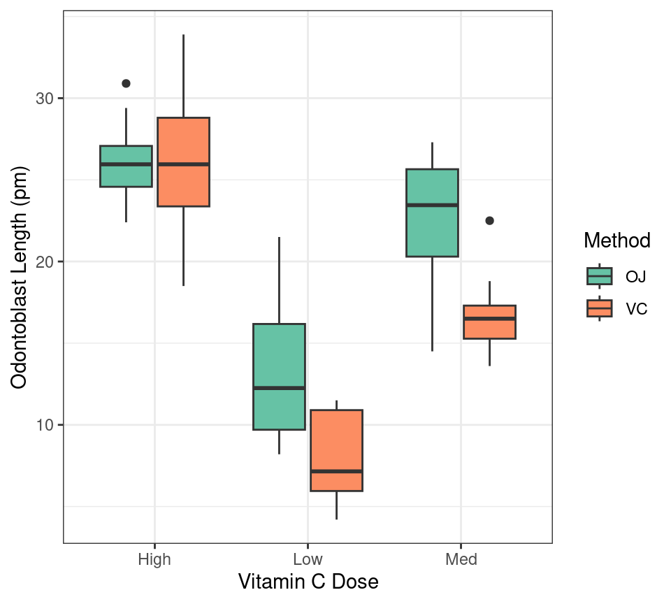

```r
ggplot(
  pigs, aes(x = dose, y = len, fill = supp)
) +
  geom_boxplot() +
  scale_fill_brewer(palette = "Set2") +
  labs(
    x = "Vitamin C Dose",
    y = "Odontoblast Length (pm)",
    fill = "Method"
  ) +
  theme_bw()
```

## Facets

- We could even show each method in it’s own panel (i.e. facet)

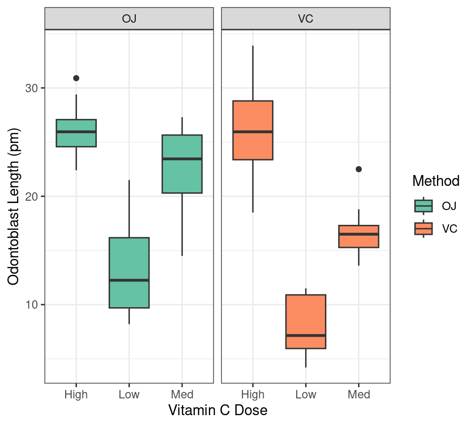

```r
ggplot(
  pigs, aes(x = dose, y = len, fill = supp)
) +
  geom_boxplot() +
  facet_wrap(~supp) +
  scale_fill_brewer(palette = "Set2") +
  labs(
    x = "Vitamin C Dose",
    y = "Odontoblast Length (pm)",
    fill = "Method"
  ) +
  theme_bw()
```

- We have easily crated a complex, highly cutsomised plot
- Much of this is near impossible with `base` plotting

# Different Geometries

## `geom_*()`

- Multiple options for geometry exist
  - Points: `geom_point()`, `geom_jitter()`
  - Bar-plots: `geom_col()`, `geom_bar()`
  - Boxplots: `geom_boxplot()`, `geom_violin()`
  - Distributions: `geom_density()`, `geom_histogram()`
  - Lines: `geom_line()`, `geom_path()`
  - Straight Lines: `geom_abline()`,`geom_hline()`, `geom_vline()`
  - Short Line Segments: `geom_errorbar()`, `geom_segment()`
  - Text: `geom_text()`, `geom_label()`
  - Heatmaps: `geom_rect()`, `geom_raster()`, `geom_tile()`

Our data will often demand a certain geometry

## Overlaying points

- Add `geom_point()` with some transparency (alpha) to the boxplot fill
  - Will be drawn before the boxplot (i.e. in order of the code)

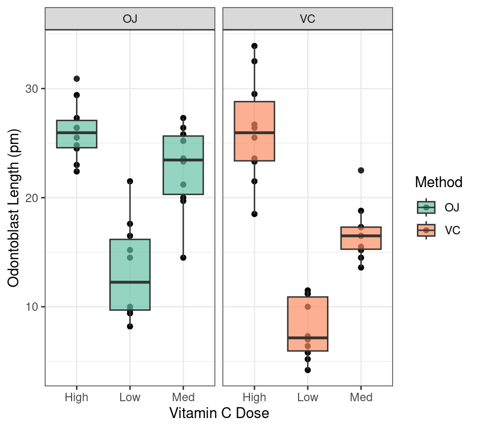

```r
ggplot(
  pigs, aes(x = dose, y = len, fill = supp)
) +
  geom_point() +
  geom_boxplot(alpha = 0.7) +
  facet_wrap(~supp) +
  scale_fill_brewer(palette = "Set2") +
  labs(
    x = "Vitamin C Dose",
    y = "Odontoblast Length (pm)",
    fill = "Method"
  ) +
  theme_bw()
```

## Overlaying points

- `geom_jitter()` is `geom_point()` with a bit of noise added
  - width & height control x & y noise respectively

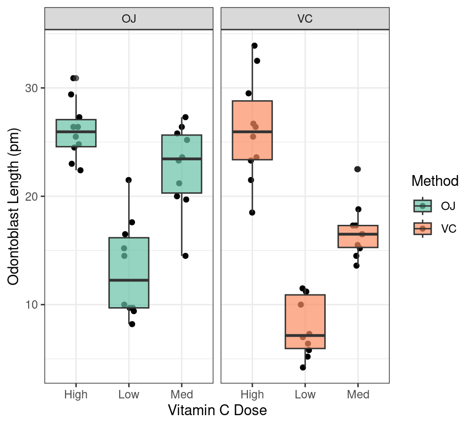

```r
ggplot(
  pigs, aes(x = dose, y = len, fill = supp)
) +
  geom_jitter(width = 0.1, height = 0) +
  geom_boxplot(alpha = 0.7) +
  facet_wrap(~supp) +
  scale_fill_brewer(palette = "Set2") +
  labs(
    x = "Vitamin C Dose",
    y = "Odontoblast Length (pm)",
    fill = "Method"
  ) +
  theme_bw()
```

# Additional Comments

## Categorical Variables

- `dose` and `supp` are categorical variables (i.e. discrete)
  - Known in `R` as `factors`
  - By default, levels are assigned in alphabetic order
  - We’ll learn more about these in the next section

## NB

- `ggplot` is the function
- `ggplot2` is the package name

. . .

- Hadley started with `ggplot` as the package name
  - Abandoned and rewrote as `ggplot2` during his PhD
  - Probably would’ve done things differently in hindsight
- The package `ggplot` is not publicly available

## Conclusion

- Beyond the first boxplot  
  $\implies$ can be very difficult to draw using `base`/`graphics`
- The dataset determines what geometry is appropriate
- Highly customisable plots
  - Colour/Fill palettes
  - Scales for axes can be log transformed, trimmed etc
  - Themes control overall appearance
- All take a while to learn
  - Practice, practice, practice
  - The *R Graphics Cookbook* is a free online resource ([here](https://r-graphics.org/))